# drug_dataset

```python
import pandas as pd
import matplotlib.pyplot as plt
import seaborn as sns

df = pd.read_csv("real_drug_dataset.csv")

df.head()
```

|  | Patient_ID | Age | Gender | Condition | Drug_Name | Dosage_mg | Treatment_Duration_days | Side_Effects | Improvement_Score |
| --- | --- | --- | --- | --- | --- | --- | --- | --- | --- |
| 0 | P0001 | 56 | Male | Infection | Ciprofloxacin | 50 | 9 | Nausea | 8.5 |
| 1 | P0002 | 69 | Male | Hypertension | Metoprolol | 500 | 24 | Tiredness | 8.7 |
| 2 | P0003 | 46 | Female | Depression | Bupropion | 100 | 25 | Dry mouth | 5.4 |
| 3 | P0004 | 32 | Male | Diabetes | Glipizide | 850 | 44 | Low blood sugar | 6.4 |
| 4 | P0005 | 60 | Male | Depression | Bupropion | 850 | 35 | Anxiety | 5.3 |

```python
df.info()
```

```
<class 'pandas.core.frame.DataFrame'>
RangeIndex: 1000 entries, 0 to 999
Data columns (total 9 columns):
 #   Column                   Non-Null Count  Dtype
---  ------                   --------------  -----
 0   Patient_ID               1000 non-null   object
 1   Age                      1000 non-null   int64
 2   Gender                   1000 non-null   object
 3   Condition                1000 non-null   object
 4   Drug_Name                1000 non-null   object
 5   Dosage_mg                1000 non-null   int64
 6   Treatment_Duration_days  1000 non-null   int64
 7   Side_Effects             1000 non-null   object
 8   Improvement_Score        1000 non-null   float64
dtypes: float64(1), int64(3), object(5)
memory usage: 70.4+ KB
```

## QUESTION 1

```python
df.describe().T
```

|  | count | mean | std | min | 25% | 50% | 75% | max |
| --- | --- | --- | --- | --- | --- | --- | --- | --- |
| Age | 1000.0 | 49.8570 | 18.114267 | 18.0 | 35.0 | 50.0 | 66.0 | 79.0 |
| Dosage_mg | 1000.0 | 352.6500 | 295.419617 | 50.0 | 100.0 | 250.0 | 500.0 | 850.0 |
| Treatment_Duration_days | 1000.0 | 32.3800 | 15.698090 | 5.0 | 19.0 | 32.0 | 46.0 | 59.0 |
| Improvement_Score | 1000.0 | 7.0152 | 1.425609 | 2.5 | 6.1 | 7.0 | 8.0 | 10.0 |

## QUESTION 2

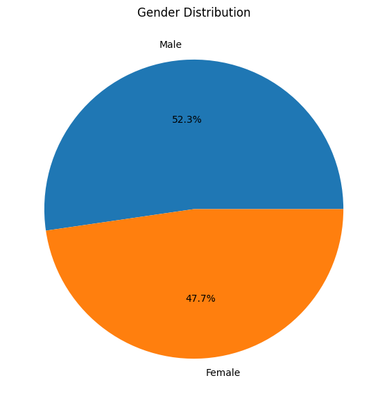

```python
categorical_cols = ["Gender", "Condition", "Drug_Name", "Side_Effects"]

plt.figure(figsize=(7, 7))
df["Gender"].value_counts().plot.pie(autopct="%1.1f%%")
plt.title("Gender Distribution")
plt.ylabel("")
plt.show()
```

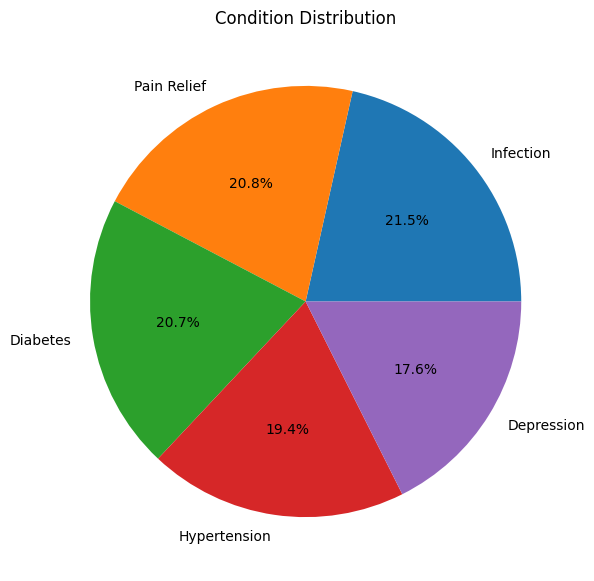

```python
plt.figure(figsize=(7, 7))
df["Condition"].value_counts().plot.pie(autopct="%1.1f%%")
plt.title("Condition Distribution")
plt.ylabel("")
plt.show()
```

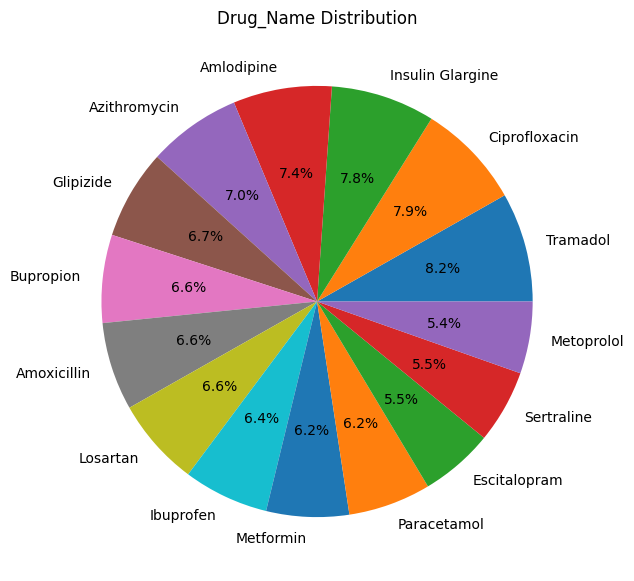

```python
plt.figure(figsize=(7, 7))
df["Drug_Name"].value_counts().plot.pie(autopct="%1.1f%%")
plt.title("Drug_Name Distribution")
plt.ylabel("")
plt.show()
```

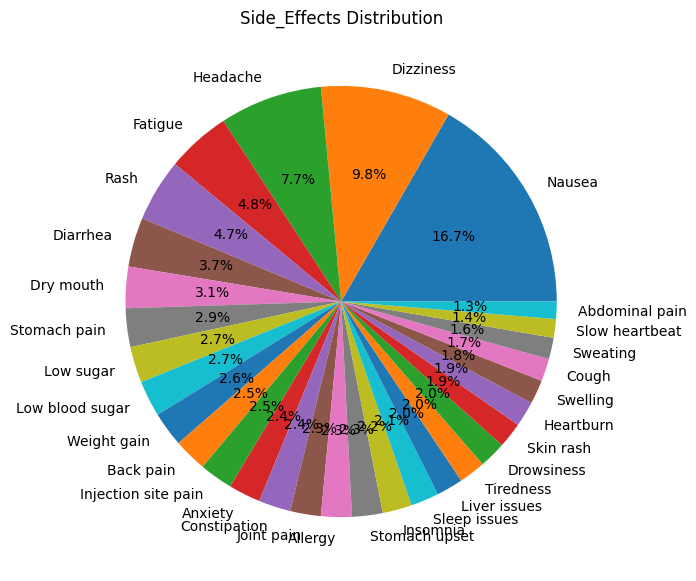

```python
plt.figure(figsize=(7, 7))
df["Side_Effects"].value_counts().plot.pie(autopct="%1.1f%%")
plt.title("Side_Effects Distribution")
plt.ylabel("")
plt.show()
```

## QUESTION 3

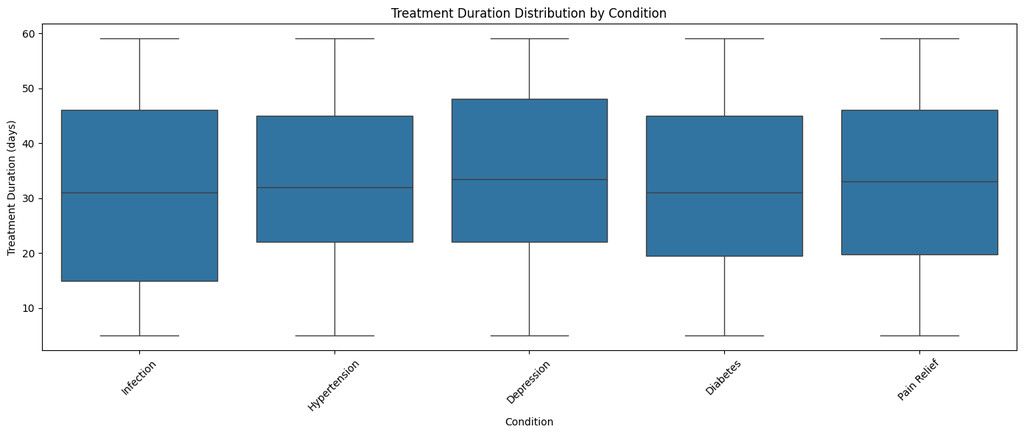

```python
plt.figure(figsize=(14, 6))
sns.boxplot(data=df, x="Condition", y="Treatment_Duration_days")

plt.xticks(rotation=45)
plt.title("Treatment Duration Distribution by Condition")
plt.ylabel("Treatment Duration (days)")
plt.xlabel("Condition")
plt.tight_layout()
plt.show()
```

## QUESTION 4

```python
freq_table = pd.crosstab(df["Drug_Name"], df["Side_Effects"])
freq_table
```

| Side_Effects Drug_Name | Abdominal pain | Allergy | Anxiety | Back pain | Constipation | Cough | Diarrhea | Dizziness | Drowsiness | Dry mouth | ... | Rash | Skin rash | Sleep issues | Slow heartbeat | Stomach pain | Stomach upset | Sweating | Swelling | Tiredness | Weight gain |
| --- | --- | --- | --- | --- | --- | --- | --- | --- | --- | --- | --- | --- | --- | --- | --- | --- | --- | --- | --- | --- | --- |
| Amlodipine | 0 | 0 | 0 | 0 | 0 | 0 | 0 | 27 | 0 | 0 | ... | 0 | 0 | 0 | 0 | 0 | 0 | 0 | 18 | 0 | 0 |
| Amoxicillin | 0 | 23 | 0 | 0 | 0 | 0 | 19 | 0 | 0 | 0 | ... | 24 | 0 | 0 | 0 | 0 | 0 | 0 | 0 | 0 | 0 |
| Azithromycin | 13 | 0 | 0 | 0 | 0 | 0 | 0 | 0 | 0 | 0 | ... | 0 | 0 | 0 | 0 | 0 | 0 | 0 | 0 | 0 | 0 |
| Bupropion | 0 | 0 | 24 | 0 | 0 | 0 | 0 | 0 | 0 | 18 | ... | 0 | 0 | 0 | 0 | 0 | 0 | 0 | 0 | 0 | 0 |
| Ciprofloxacin | 0 | 0 | 0 | 0 | 0 | 0 | 0 | 28 | 0 | 0 | ... | 0 | 0 | 0 | 0 | 0 | 0 | 0 | 0 | 0 | 0 |
| Escitalopram | 0 | 0 | 0 | 0 | 0 | 0 | 0 | 0 | 0 | 0 | ... | 0 | 0 | 21 | 0 | 0 | 0 | 16 | 0 | 0 | 0 |
| Glipizide | 0 | 0 | 0 | 0 | 0 | 0 | 0 | 0 | 0 | 0 | ... | 0 | 19 | 0 | 0 | 0 | 0 | 0 | 0 | 0 | 0 |
| Ibuprofen | 0 | 0 | 0 | 0 | 0 | 0 | 0 | 0 | 0 | 0 | ... | 0 | 0 | 0 | 0 | 29 | 0 | 0 | 0 | 0 | 0 |
| Insulin Glargine | 0 | 0 | 0 | 0 | 0 | 0 | 0 | 0 | 0 | 0 | ... | 0 | 0 | 0 | 0 | 0 | 0 | 0 | 0 | 0 | 26 |
| Losartan | 0 | 0 | 0 | 25 | 0 | 17 | 0 | 0 | 0 | 0 | ... | 0 | 0 | 0 | 0 | 0 | 0 | 0 | 0 | 0 | 0 |
| Metformin | 0 | 0 | 0 | 0 | 0 | 0 | 18 | 0 | 0 | 0 | ... | 0 | 0 | 0 | 0 | 0 | 23 | 0 | 0 | 0 | 0 |
| Metoprolol | 0 | 0 | 0 | 0 | 0 | 0 | 0 | 20 | 0 | 0 | ... | 0 | 0 | 0 | 14 | 0 | 0 | 0 | 0 | 20 | 0 |
| Paracetamol | 0 | 0 | 0 | 0 | 0 | 0 | 0 | 0 | 0 | 0 | ... | 23 | 0 | 0 | 0 | 0 | 0 | 0 | 0 | 0 | 0 |
| Sertraline | 0 | 0 | 0 | 0 | 0 | 0 | 0 | 0 | 20 | 13 | ... | 0 | 0 | 0 | 0 | 0 | 0 | 0 | 0 | 0 | 0 |
| Tramadol | 0 | 0 | 0 | 0 | 24 | 0 | 0 | 23 | 0 | 0 | ... | 0 | 0 | 0 | 0 | 0 | 0 | 0 | 0 | 0 | 0 |

15 rows × 30 columns

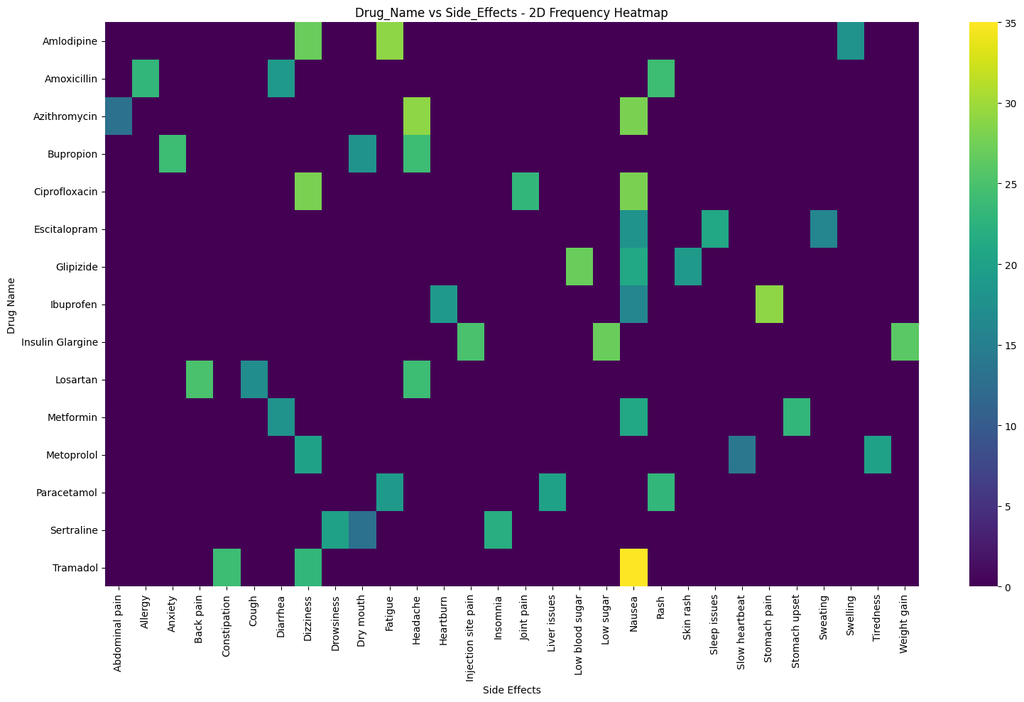

```python
plt.figure(figsize=(16, 10))
sns.heatmap(freq_table, cmap="viridis")
plt.title("Drug_Name vs Side_Effects - 2D Frequency Heatmap")
plt.xlabel("Side Effects")
plt.ylabel("Drug Name")
plt.tight_layout()
plt.show()
```

## QUESTION 5

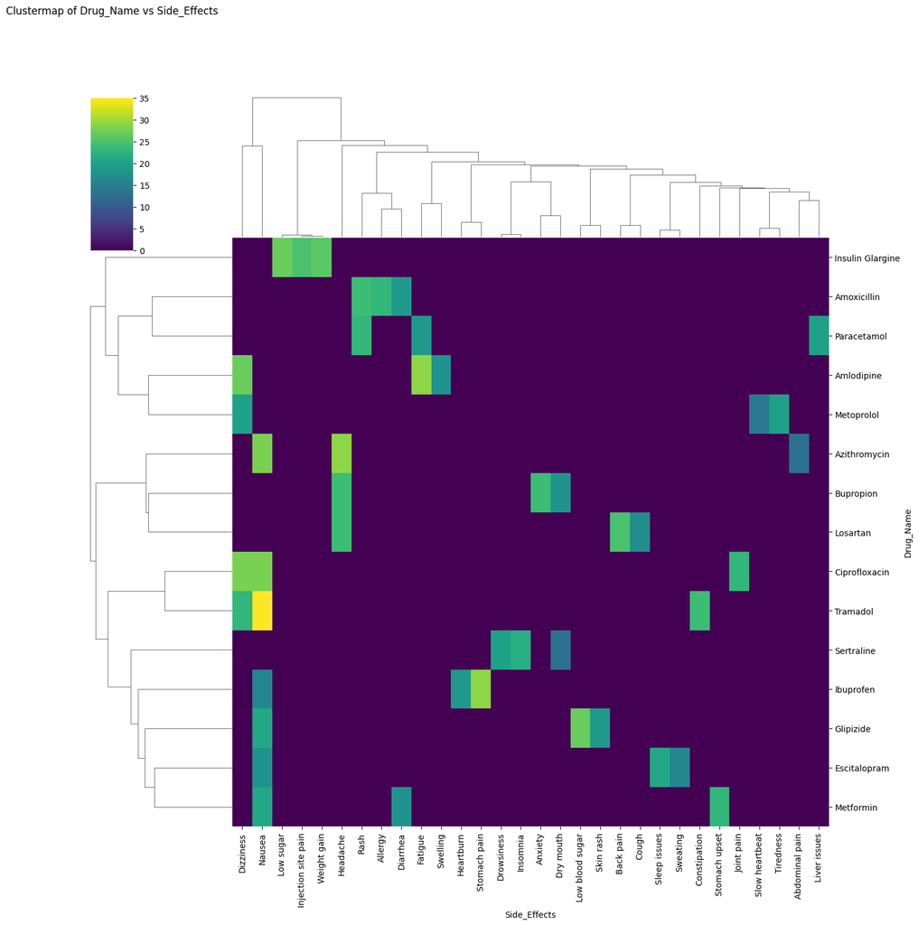

```python
plt.figure(figsize=(12, 12))

sns.clustermap(
    freq_table,
    cmap="viridis",
    figsize=(14, 14),
    metric="euclidean",
    method="ward",
    linewidths=0
)

plt.title("Clustermap of Drug_Name vs Side_Effects", pad=100)
plt.show()
```

Overall, the clustermap reveals meaningful structure:

Drugs with comparable adverse-effect patterns cluster together,

Frequently reported side effects group into shared clusters,

Rare effects distribute into diffuse, low-density regions.

This hierarchical organization confirms that the dataset exhibits coherent and interpretable drug–side-effect relationships.

## QUESTION 6

```python
corr_pearson = df[["Age", "Improvement_Score"]].corr(method="pearson")
print("Pearson correlation matrix:")
print(corr_pearson)

# İstersen Spearman da bakabilirsin:
corr_spearman = df[["Age", "Improvement_Score"]].corr(method="spearman")
print("\nSpearman correlation matrix:")
print(corr_spearman)
```

```
Pearson correlation matrix:
                        Age  Improvement_Score
Age                1.000000           0.010546
Improvement_Score  0.010546           1.000000

Spearman correlation matrix:
                        Age  Improvement_Score
Age                1.000000           0.011759
Improvement_Score  0.011759           1.000000
```

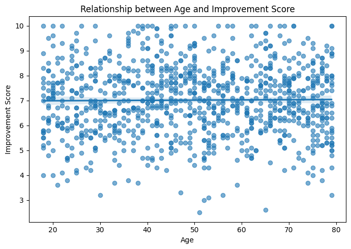

```python
plt.figure(figsize=(7, 5))
sns.regplot(
    data=df,
    x="Age",
    y="Improvement_Score",
    scatter_kws={"alpha": 0.6}
)
plt.title("Relationship between Age and Improvement Score")
plt.xlabel("Age")
plt.ylabel("Improvement Score")
plt.tight_layout()
plt.show()
```

Both the Pearson (0.0105) and Spearman (0.0117) correlation coefficients indicate an extremely weak positive association between Age and Improvement_Score. These values are very close to zero, suggesting that there is no meaningful linear or monotonic relationship between the two variables.

The scatter plot supports this conclusion: data points are widely dispersed across all age ranges, and the regression line is nearly flat. This indicates that patients' improvement levels are essentially independent of age, and age does not appear to be a predictive factor for treatment improvement in this dataset.

In summary, the analysis provides strong evidence that Age has no significant influence on Improvement_Score.

## OUESTION 7

```python
normalized = (
    df.groupby("Gender")["Condition"]
      .value_counts(normalize=True)
      .rename("Probability")
      .reset_index()
)

print(normalized)
```

```
   Gender     Condition  Probability
0  Female     Infection     0.238994
1  Female      Diabetes     0.213836
2  Female   Pain Relief     0.192872
3  Female  Hypertension     0.178197
4  Female    Depression     0.176101
5    Male   Pain Relief     0.221797
6    Male  Hypertension     0.208413
7    Male      Diabetes     0.200765
8    Male     Infection     0.193117
9    Male    Depression     0.175908
```

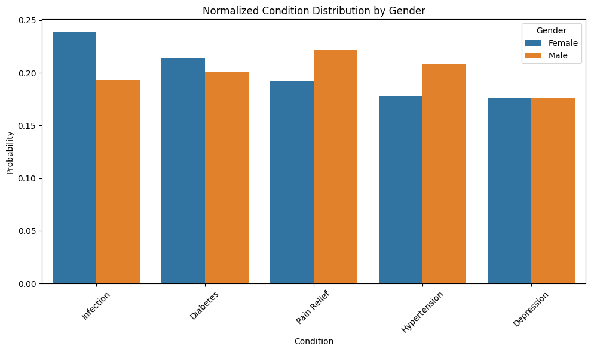

```python
plt.figure(figsize=(10, 6))
sns.barplot(
    data=normalized,
    x="Condition",
    y="Probability",
    hue="Gender"
)

plt.xticks(rotation=45)
plt.title("Normalized Condition Distribution by Gender")
plt.tight_layout()
plt.show()
```

## QUESTION 8

```python
dizziness_df = df[df["Side_Effects"] == "Dizziness"]

dizziness_counts = dizziness_df["Drug_Name"].value_counts()

print("Drugs with reported Dizziness side effect (sorted):")
print(dizziness_counts)
```

```
Drugs with reported Dizziness side effect (sorted):
Drug_Name
Ciprofloxacin    28
Amlodipine       27
Tramadol         23
Metoprolol       20
Name: count, dtype: int64
```

## OUESTION 9

```python
df[df["Drug_Name"] == "Metoprolol"]["Side_Effects"].value_counts()
```

| Side_Effects | count |
| --- | --- |
| Tiredness | 20 |
| Dizziness | 20 |
| Slow heartbeat | 14 |

**dtype:** int64

```python
meto = df[df["Drug_Name"] == "Metoprolol"]

total_side_effects = meto.shape[0]

dizziness_count = (meto["Side_Effects"] == "Dizziness").sum()

prob = dizziness_count / total_side_effects

print("Total side effects reported for Metoprolol:", total_side_effects)
print("Dizziness count:", dizziness_count)
print("Probability of Dizziness:", prob)
```

```
Total side effects reported for Metoprolol: 54
Dizziness count: 20
Probability of Dizziness: 0.37037037037037035
```